# Przykłady i rozwiązania

Michał Burdukiewicz

11-05-2024

Źródło danych: https://github.com/michbur/polish-driver-license

## Rysunek 1

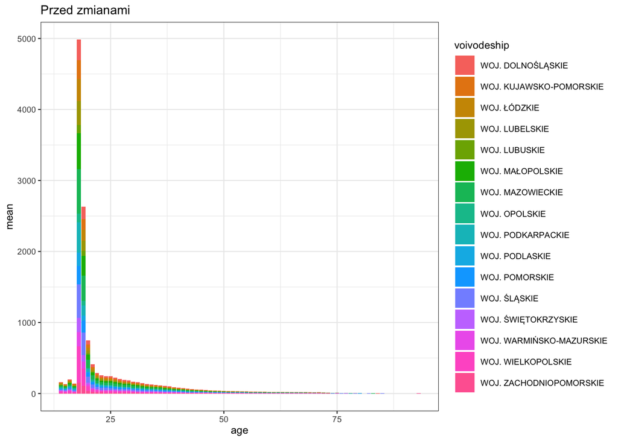

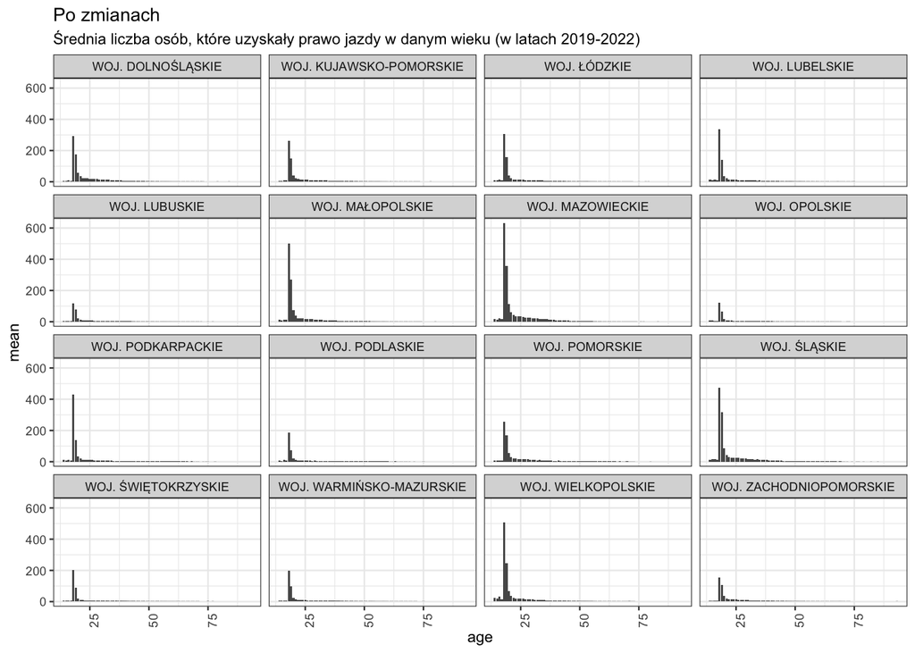

Cel: pokazanie średniej liczby osób, które uzyskały prawo jazdy w danym wieku w zależności od województwa.

**Atrybuty wizualne** - oś X - wiek, oś Y - średnia liczba osób, ujednolicenie koloru

**Geometria**:

- zmiana wykresu na słupkowy
- wydaje nam się, że odcięcie na osi Y będzie konieczne (bo około 18 lat są najwyższe wartości), ale z pierwszego rysunku nie jesteśmy pewni czy będzie to konieczne.

**Fasety**: fasetowanie per województwo (podpisać każdy kafelek wybranym województwem, dopasówać czcionke, wielkość do najdłuższej nazwy)

**Temat**: tytuł - Średnia liczba osób, które uzyskały prawo jazdy w danym wieku (z lat yyyy - yyyy)

## Rysunek 2

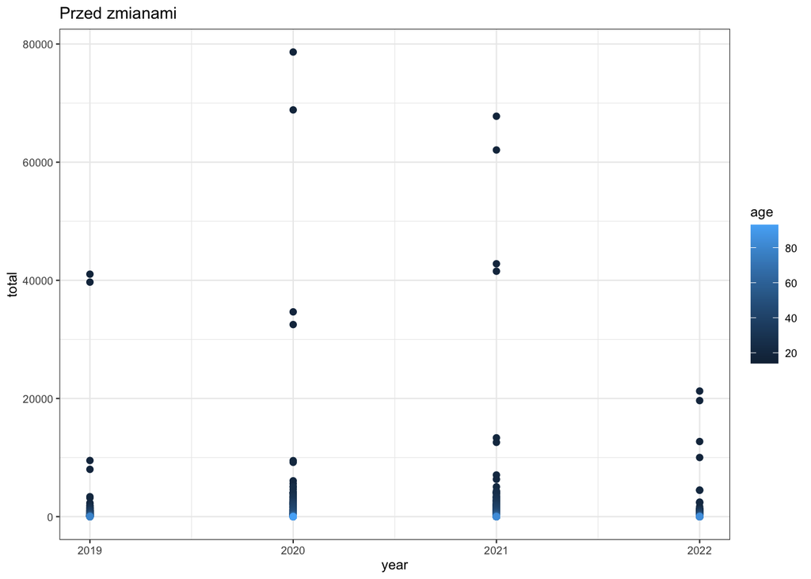

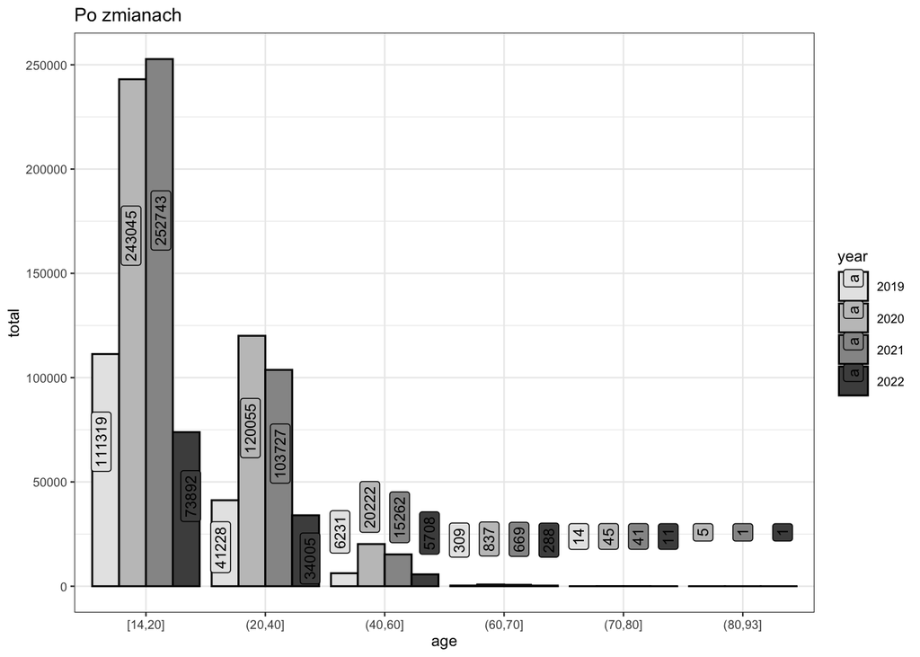

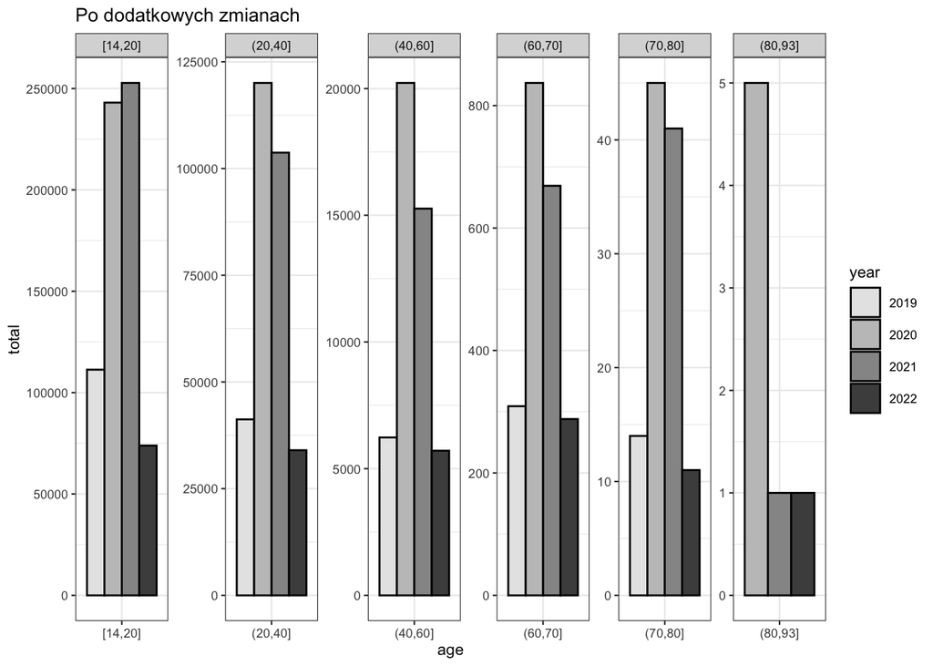

Cel: pokazanie liczby osób w danym wieku uzyskujących prawo jazdy w danym roku.

G Wykres slupkowy bylby dobrym pomyslem

[AW] Dzielimy na lata, - oś X to przedziały wiekowe w każdym roku - każdy otagowany innym kolorem (by pomóc zestawic ze soba przedzialy wiekowe)

Przedziały wiekowe dobrze byłoby pokazac w kohortach (10-letnich) i zaznaczyc je roznymi kolorami (nie gradientem) ale paletą kolorów monochromatycznych

[F] - niekonieczne

S - zostajemy przy zliczaniu

## Rysunek 3

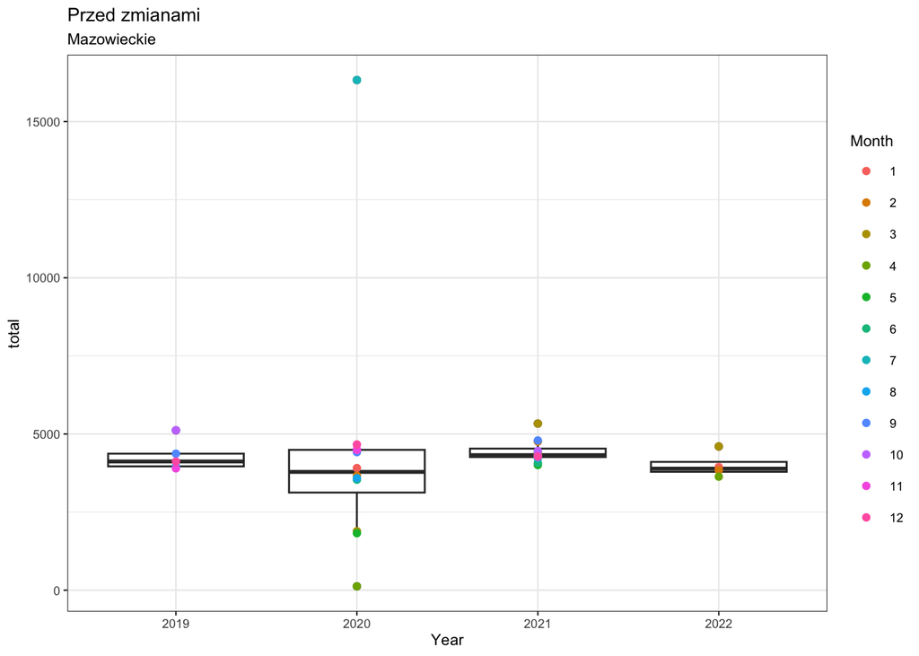

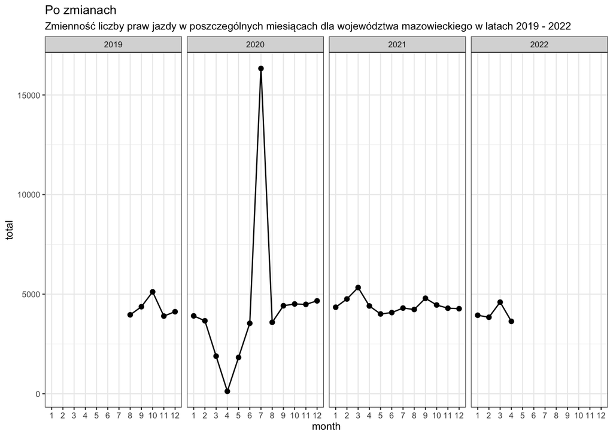

Cel: pokazanie zmienności liczby uzyskanych praw jazdy w skali roku w zależności od roku w województwie mazowieckim.

Propozycja 1: robimy 4 fasety dla każdego roku, w każdym roku pokazujemy liczbę praw jazdy vs numer miesiąca . Wykres liniowy. [AW] oś Y liczba praw jazdy; oś X numer miesiąca; Tytuł “Zmienność liczby praw jazdy w poszczególnych miesiącach dla wijewództwa mazowieckiego w latach 2019 - 2022” G Wykres liniowy, zaznaczony punkt dla każdego miesiąca, nieciąglóść dla outliera wpływa na wszystkie osie Y [F] Faset per rok S Wartość dla każdego miesiąca/roku

## Rysunek 4

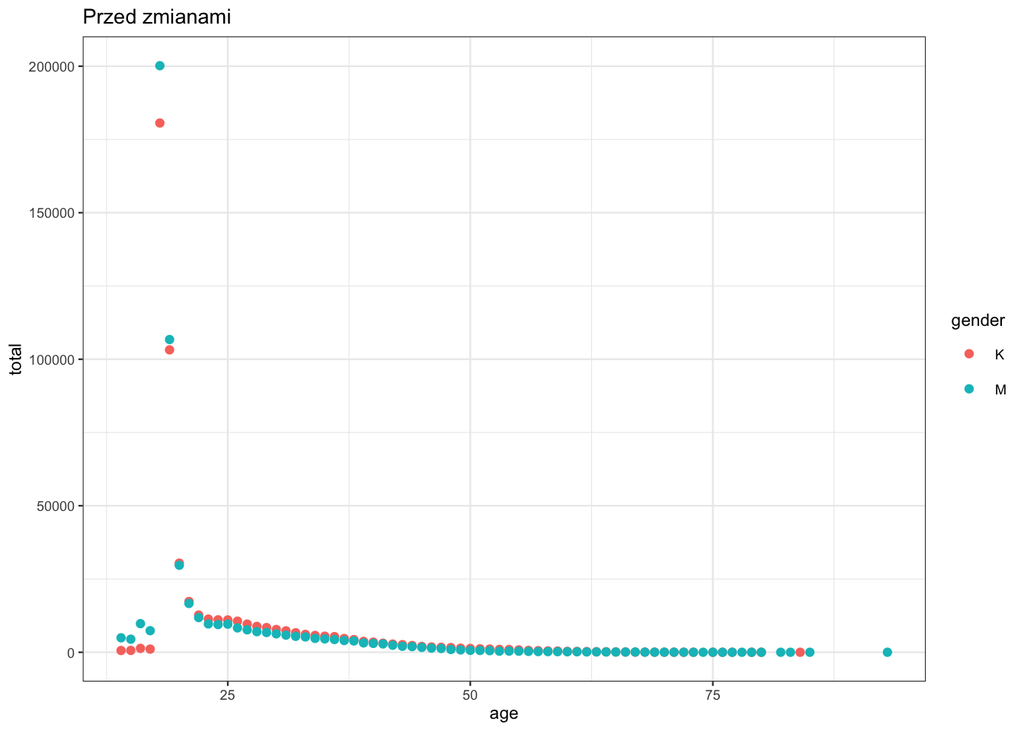

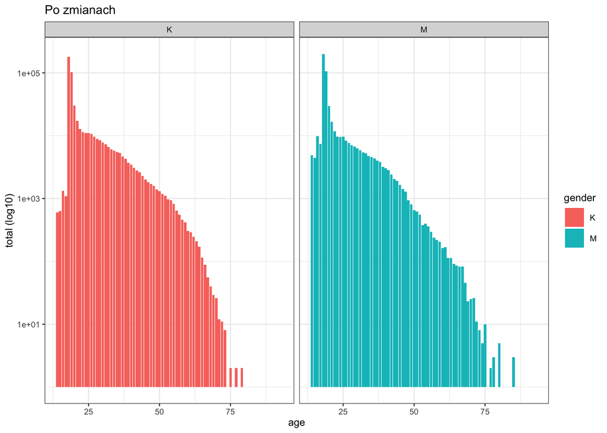

Cel: pokazać zależność liczby uzyskanych praw jazdy w zależności od wieku i płci.

G4 - Propozycja: Zmiana skali wykresu na logarytmiczną (oś Y), Poprawa etykiet osi Y -> spacja co 3 znaki

## Rysunek 5

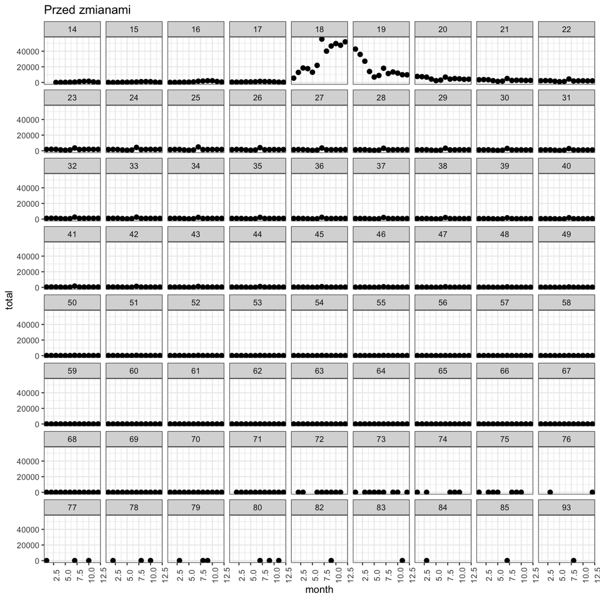

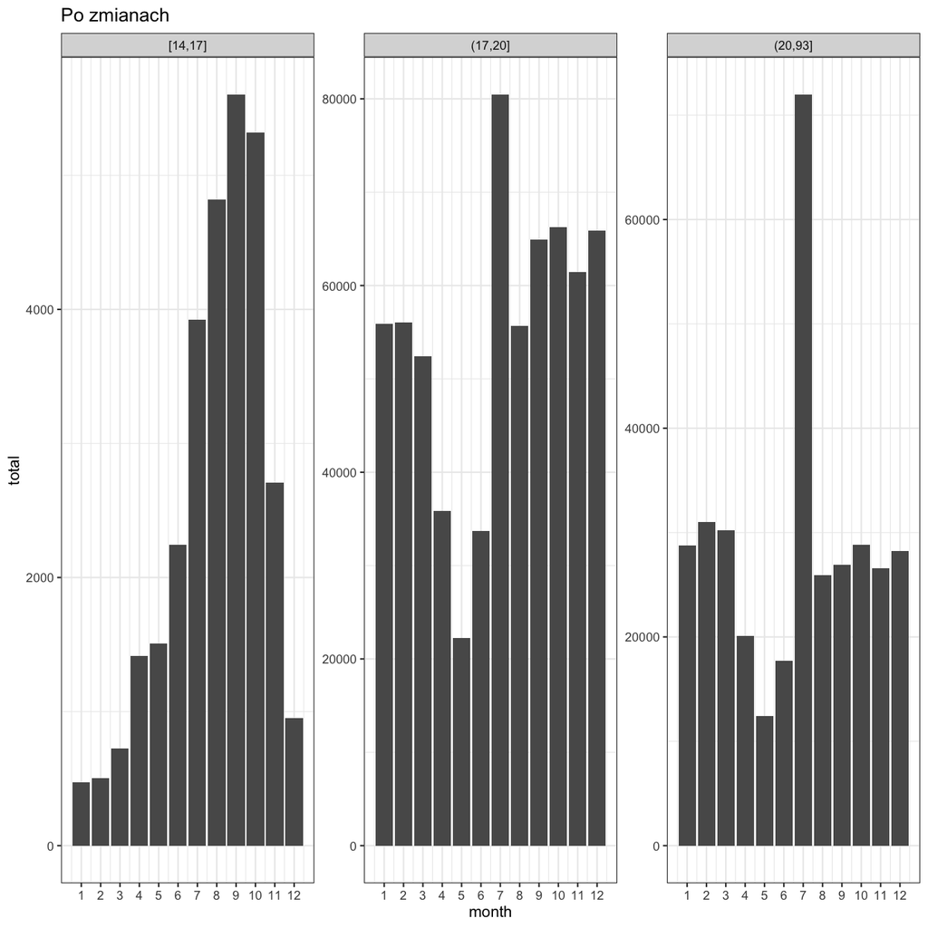

Cel: pokazać liczbę praw jazdy uzyskiwanych przez osoby w różnym wieku w zależności od miesiąca.

pozostaje: - na osi X miesiące roku (unormowanie do int liczby zamiast istniejących liczb ułamkowych) - na osi Y - liczba praw jazdy ( taka sama oś dla wszystkich dekad oprócz <18,19>)

- Zmiana tylko fasetów (faset?)
- Fasetowanie po dekadach (wiek)
- Osobne fasety dla outlierów: 18 i 19 rok życia
- wykres słupkowy ??

## Rysunek 6

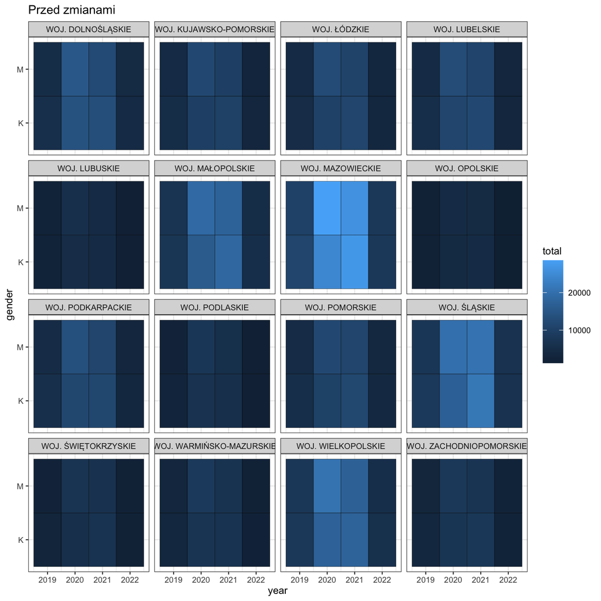

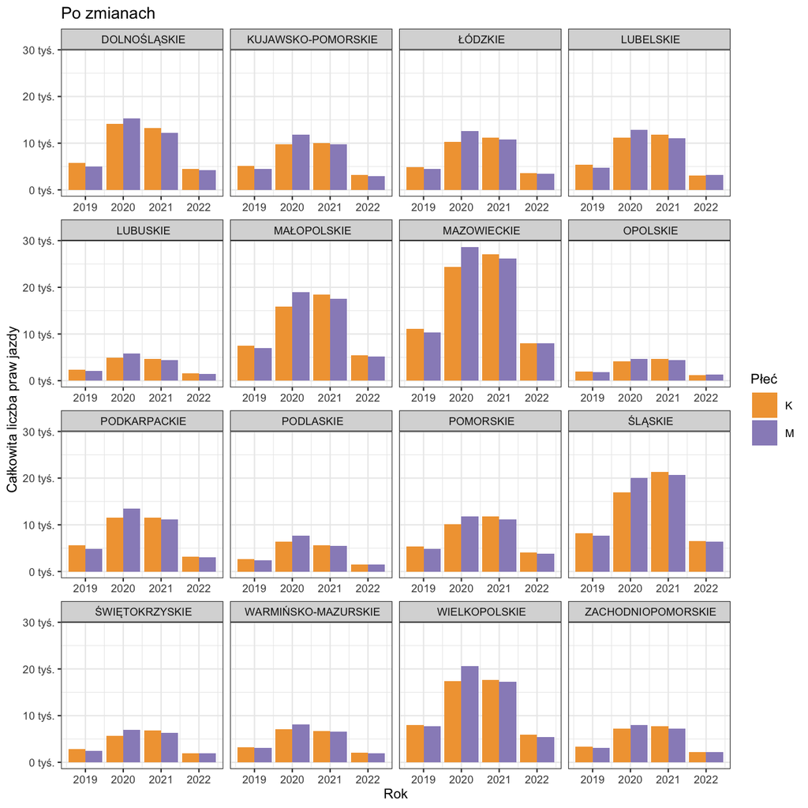

Cel: pokazać liczbę uzyskanych praw jazdy dla poszczególnych województw w zależności od płci i roku.

[AW]: oś X - rok, oś Y - liczba wydanych praw jazdy*; podział na płcie (kolorami; np. #f1a340 i #998ec3), zamiast wielu zer przy liczbie - wyrazic wartośc w tysiącach (10 tys. zamiast 10000); oś X - dodanie znaczników osi dla każdego wykresu

- do rozważenia – dodanie nieciągłości osi Y dla woj. mazowieckiego

[F]: usunąc z opsiu “woj.” i dopasowac czcionkę tak, żeby się mieściło

[inne] zamiana opisów osi na język polski (konsystencja językowa)